# Homework Answers

Cui Yangbo

2024-12-07

# Questions

Use knitr to produce at least 3 examples. For each example, texts should mix with figures and/or tables. Better to have mathematical formulas.

## Answers

### Example 1

We will

- generate normal distributed samples.
- generate a histogram.

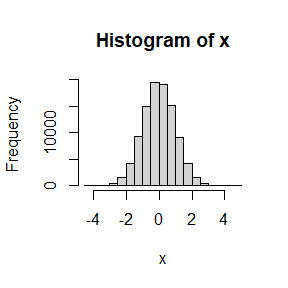

```r
x = rnorm(100000)
hist(x)
```

### Example 2

We will estimate $\pi$ by using Monte Carlo method:

- Let $n$ be the number of random points to generate
- Let $I$ be the numbers of points inside the unit circle.
- Then the estimated $\pi$ will be
  $$\pi=\dfrac{4I}{n}$$

```r
estimate_pi <- function(n) {
  I <- 0
  for (i in 1:n) {
    # Generate random x and y coordinates between -1 and 1
    x <- runif(1, -1, 1)
    y <- runif(1, -1, 1)
    # Check if the point is inside the unit circle
    if (x^2 + y^2 <= 1) {
      I <- I + 1
    }
  }
  # Estimate pi
  return (4 * I / n)
}

# Generate different numbers of points
points <- c(10^1, 10^2, 10^3, 10^4, 10^5)
pi_estimates <- sapply(points, estimate_pi)

# Display results
data.frame(Number_of_Points = points, Estimated_Pi = pi_estimates)
```

```
##   Number_of_Points Estimated_Pi
## 1            1e+01      3.60000
## 2            1e+02      3.08000
## 3            1e+03      3.20800
## 4            1e+04      3.17880
## 5            1e+05      3.13988
```

### Example 3

Here we will

- calculate the correlation-coefficient matrix between variables in the state.x77 dataset.
- draw the visualization graph of the correlation coefficient matrix.

```r
(R = cor(state.x77))
```

```
##             Population     Income  Illiteracy    Life Exp     Murder
## Population  1.00000000  0.2082276  0.10762237 -0.06805195  0.3436428
## Income      0.20822756  1.0000000 -0.43707519  0.34025534 -0.2300776
## Illiteracy  0.10762237 -0.4370752  1.00000000 -0.58847793  0.7029752
## Life Exp   -0.06805195  0.3402553 -0.58847793  1.00000000 -0.7808458
## Murder      0.34364275 -0.2300776  0.70297520 -0.78084575  1.0000000
## HS Grad    -0.09848975  0.6199323 -0.65718861  0.58221620 -0.4879710
## Frost      -0.33215245  0.2262822 -0.67194697  0.26206801 -0.5388834
## Area        0.02254384  0.3633154  0.07726113 -0.10733194  0.2283902
##                HS Grad      Frost        Area
## Population -0.09848975 -0.3321525  0.02254384
## Income      0.61993232  0.2262822  0.36331544
## Illiteracy -0.65718861 -0.6719470  0.07726113
## Life Exp    0.58221620  0.2620680 -0.10733194
## Murder     -0.48797102 -0.5388834  0.22839021
## HS Grad     1.00000000  0.3667797  0.33354187
## Frost       0.36677970  1.0000000  0.05922910
## Area        0.33354187  0.0592291  1.00000000
```

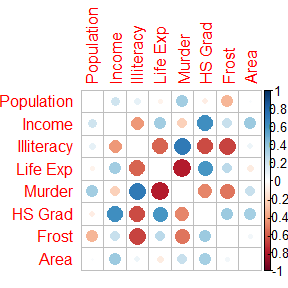

```r
corrplot(R,diag=F)
```

# Question 3.4

The Rayleigh density [156, Ch. 18] is

$$f(x)=\frac
x{\sigma^2}\:e^{-x^2/(2\sigma^2)},\quad
x\geq0,\:\sigma>0.$$

Develop an algorithm to generate random samples from a Rayleigh $(\sigma)$ distribution. Generate Rayleigh $(\sigma)$ samples for several choices of $\sigma>0$ and check that the mode of the generated samples is close to the theoretical mode $\sigma$ (check the histogram).

## Answer to 3.4

- 首先根据pdf计算cdf

$$F(x)=1-e^{-x^{2}/(2\sigma^{2})},x\geq0$$

- 然后，令$U$为$[0,1]$上均匀分布的r.v.，设

$$U=F(X)$$

解出

$$X=\sigma\sqrt{-2\ln(u)}$$

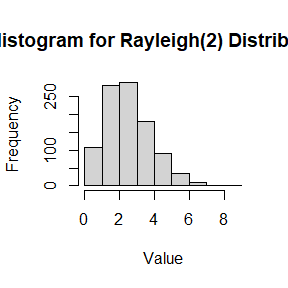

```
## Theoretical mode for sigma = 2 is 2
## mode of the generated samples for sigma = 2 is 2.118617
```

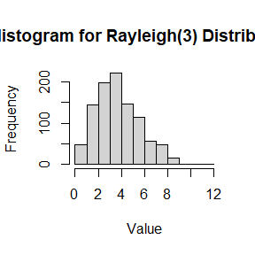

```
## Theoretical mode for sigma = 3 is 3
## mode of the generated samples for sigma = 3 is 3.06303
```

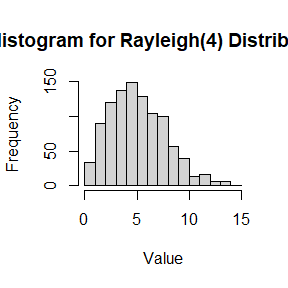

```
## Theoretical mode for sigma = 4 is 4
## mode of the generated samples for sigma = 4 is 4.041771
```

```r
# generate random samples from a Rayleigh $(\sigma)$ distribution
set.seed(123456)
rayleigh <- function(sigma) {
  n <- 1000
  U <- runif(n)
  return(sigma * sqrt(-2 * log(U)))
}
# Generate Rayleigh $(\sigma)$ samples for several choices of $\sigma>0$
sigma_values <- c(2, 3, 4)

for (sigma in sigma_values) {
  samples <- rayleigh(sigma)

  # check the histogram
  hist(
    samples,
    main = paste("Histogram for Rayleigh(", sigma, ") Distribution", sep = ""),
    xlab = "Value",
    ylab = "Frequency"
  )

  # Theoretical mode is sigma
  cat("Theoretical mode for sigma =", sigma, "is", sigma, "\n")

  # Estimated mode from histogram
  estimated_mode <- density(samples)$x[which.max(density(samples)$y)]
  cat("mode of the generated samples for sigma =",
      sigma,
      "is",
      estimated_mode,
      "\n")
}
```

# Question 3.11

Generate a random sample of size 1000 from a normal location mixture. The components of the mixture have $N(0,1)$ and $N(3,1)$ distributions with mixing probabilities $p_1$ and $p_2=1 − p_1$. Graph the histogram of the sample with density superimposed, for $p_1 = 0.75$. Repeat with different values for $p_1$ and observe whether the empirical distribution of the mixture appears to be bimodal. Make a conjecture about the values of $p_1$ that produce bimodal mixtures.

## Answer to 3.11

- 首先定义一个函数能够Generate a random sample of size 1000 from a normal location mixture.

```r
set.seed(123456)
normal_mixture <- function(p_1) {
  p_2 <- 1 - p_1
  n <- 1000
  sample_with_mean_0 <- rnorm(n * p_1, 0, 1)
  sample_with_mean_3 <- rnorm(n * p_2, 3, 1)
  mixture_sample = c(sample_with_mean_0, sample_with_mean_3)

  # Graph the histogram of the sample with density superimposed
  p = ggplot(data = data.frame(x = mixture_sample), aes(x = x, label = "Density")) +
    geom_histogram(
      aes(y = after_stat(density)),
      binwidth = 0.5,
      color = "black",
      fill = "gray"
    ) +
    stat_density(geom = "line", color = "red") +
    ggtitle(paste0("Histogram of Mixture Distribution with p1 = ", p_1)) +
    theme_classic() +
    theme(plot.title = element_text(hjust = 0.5))
  print(p)
  return(p)
}
```

- 对$p_1 = 0.75, 0.5, 0.25, 0.1$ 绘制样本的直方图并叠加密度曲线

```r
for (p_1 in c(0.75, 0.5, 0.25, 0.1)) {
  normal_mixture(p_1)
}
```

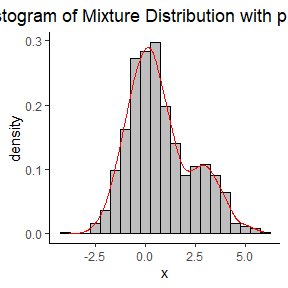

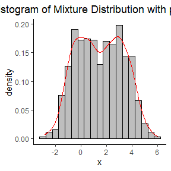

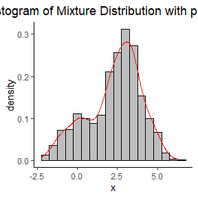

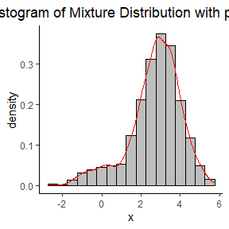

- observe whether the empirical distribution of the mixture appears to be bimodal
  - 当$p_1 = 0.75$时：
    - 大部分样本来自均值为0的正态分布，此时经验分布更倾向于单峰，且峰的位置接近均值0。虽然有一小部分样本来自均值为3的正态分布，但不足以形成明显的双峰。
  - 当$p_1 = 0.5$时：
    - 样本均匀地来自两个正态分布，此时经验分布更有可能呈现双峰。因为两个正态分布对混合分布的贡献相当，所以在均值0和3附近都有较高的概率密度，从而形成双峰。
  - 当$p_1 = 0.25$时：
    - 大部分样本来自均值为3的正态分布，此时经验分布更倾向于单峰，且峰的位置接近均值3。虽然有一小部分样本来自均值为0的正态分布，但不足以形成明显的双峰。
  - 当$p_1 = 0.1$时：
    - 绝大多数样本来自均值为3的正态分布，经验分布是单峰的，且峰接近均值3。
- Make a conjecture about the values of $p_1$ that produce bimodal mixtures
  - 基于上述观察，可以推测当 $p_1$ 接近0.5时，混合分布的经验分布更有可能是双峰的。
  - 当 $p_1$ 接近0或1时，混合分布的经验分布更倾向于单峰。

# Question 3.20

A compound Poisson process is a stochastic process $\{X(t), t\geq 0\}$ that can be represented as the random sum $X( t) = \sum _{i= 1}^{N(t)}Y_i$, $t\geq 0$, where $\{N(t), t\geq 0\}$ is a Poisson process and $Y_1,Y_2,\ldots$ are iid and independent of $\{N(t),t\geq0\}.$ Write a program to simulate a compound Poisson$(\lambda)$–Gamma process ($Y$ has a Gamma distribution). Estimate the mean and the variance of $X(10)$ for several choices of the parameters and compare with the theoretical values. Hint: Show that $E[X(t)]=\lambda tE[Y_1]$ and $Var(X(t))=\lambda tE[Y_1^2].$

## Answer to 3.20

- 首先定义一个函数能够 simulate a compound Poisson$(\lambda)$–Gamma process

```r
set.seed(123456)
compound_poisson_gamma <- function(lambda, shape, scale, t) {
  N <- rpois(1, lambda * t)
  if (N == 0) {
    return(0)
  } else {
    Y <- rgamma(N, shape = shape, scale = scale)
    return(sum(Y))
  }
}
```

- Estimate the mean and the variance of $X(10)$ for several choices of the parameters

```r
lambda <- c(1, 2, 3)
shape <- c(2, 3, 4)
scale <- c(1, 2, 3)
num_sims <- 1000
t <- 10
results <- data.frame(
  lambda = rep(lambda, each = length(shape) * length(scale)),
  shape = rep(rep(shape, each = length(scale)), length(lambda)),
  scale = rep(scale, length(lambda) * length(shape)),
  simulated_mean = NA,
  theoretical_mean = NA,
  mean_error = NA,
  simulated_var = NA,
  theoretical_var = NA,
  var_error = NA
)
for (i in 1:nrow(results)) {
  sims <- replicate(
    num_sims,
    compound_poisson_gamma(results$lambda[i], results$shape[i], results$scale[i], t)
  )
  results$simulated_mean[i] <- mean(sims)
  results$simulated_var[i] <- var(sims)
  results$theoretical_mean[i] <- results$lambda[i] * t * (results$shape[i] * results$scale[i])
  results$theoretical_var[i] <- results$lambda[i] * t * (results$shape[i] * (results$shape[i] +
                                                                               1) * results$scale[i] ^ 2)
  results$mean_error <- abs(results$simulated_mean[i] - results$theoretical_mean[i]) /
    results$theoretical_mean[i]
  results$var_error <- abs(results$simulated_var[i] - results$theoretical_var[i]) /
    results$theoretical_var[i]
}
```

- 打印结果，比较

```r
print(results, width = 1000)
```

```
##    lambda shape scale simulated_mean theoretical_mean mean_error simulated_var theoretical_var  var_error
## 1       1     2     1       19.82064               20 0.01192953      57.12574              60 0.03157004
## 2       1     2     2       40.19185               40 0.01192953     247.10387             240 0.03157004
## 3       1     2     3       59.79225               60 0.01192953     538.17146             540 0.03157004
## 4       1     3     1       29.64736               30 0.01192953     113.62446             120 0.03157004
## 5       1     3     2       60.26964               60 0.01192953     469.40774             480 0.03157004
## 6       1     3     3       90.15474               90 0.01192953    1070.78623            1080 0.03157004
## 7       1     4     1       39.51477               40 0.01192953     191.94215             200 0.03157004
## 8       1     4     2       80.42041               80 0.01192953     859.69523             800 0.03157004
## 9       1     4     3      119.89646              120 0.01192953    1878.63391            1800 0.03157004
## 10      2     2     1       40.50329               40 0.01192953     130.62600             120 0.03157004
## 11      2     2     2       79.89261               80 0.01192953     488.47292             480 0.03157004
## 12      2     2     3      119.64917              120 0.01192953    1033.00084            1080 0.03157004
## 13      2     3     1       59.44828               60 0.01192953     255.51845             240 0.03157004
## 14      2     3     2      119.41519              120 0.01192953     998.29104             960 0.03157004
## 15      2     3     3      181.68217              180 0.01192953    2214.13450            2160 0.03157004
## 16      2     4     1       79.20964               80 0.01192953     416.24964             400 0.03157004
## 17      2     4     2      160.57931              160 0.01192953    1597.16350            1600 0.03157004
## 18      2     4     3      235.82484              240 0.01192953    3709.75021            3600 0.03157004
## 19      3     2     1       60.17564               60 0.01192953     184.37009             180 0.03157004
## 20      3     2     2      119.23079              120 0.01192953     734.18402             720 0.03157004
## 21      3     2     3      178.60215              180 0.01192953    1559.33297            1620 0.03157004
## 22      3     3     1       89.16983               90 0.01192953     369.00748             360 0.03157004
## 23      3     3     2      181.66896              180 0.01192953    1520.52386            1440 0.03157004
## 24      3     3     3      268.91739              270 0.01192953    3324.37114            3240 0.03157004
## 25      3     4     1      120.76818              120 0.01192953     627.01148             600 0.03157004
## 26      3     4     2      239.63283              240 0.01192953    2457.25450            2400 0.03157004
## 27      3     4     3      355.70537              360 0.01192953    5229.52176            5400 0.03157004
```

- 绘制模拟均值与理论均值的对比图：

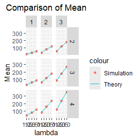

```r
ggplot(results, aes(x = lambda, y = simulated_mean, color = "Simulation")) +
  geom_point() +
  geom_line(aes(y = theoretical_mean, color = "Theory")) +
  facet_grid(shape ~ scale) +
  labs(title = "Comparison of Mean", x = "lambda", y = "Mean") +
  theme(plot.title = element_text(hjust = 0.5))
```

- 模拟方差与理论方差的对比图

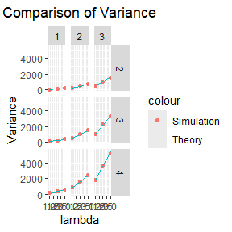

```r
ggplot(results, aes(x = lambda, y = simulated_var, color = "Simulation")) +
  geom_point() +
  geom_line(aes(y = theoretical_var, color = "Theory")) +
  facet_grid(shape ~ scale) +
  labs(title = "Comparison of Variance", x = "lambda", y = "Variance") +
  theme(plot.title = element_text(hjust = 0.5))
```

根据比较，可以认为

$$E[X(t)]=\lambda tE[Y_1]\qquad
Var(X(t))=\lambda tE[Y_1^2].$$

# Question 5.4

Write a function to compute a Monte Carlo estimate of the Beta(3, 3) cdf, and use the function to estimate $F(x)$ for $x = 0.1,0.2,...,0.9.$ Compare the estimates with the values returned by the **pbeta** function in R.

## Answer to 5.4

- 生成计算 Beta(3, 3)分布的 CDF 的Monte Carlo estimate的函数

```r
set.seed(12345)
monte_carlo_beta_cdf_mean <- function(x) {
  u <- rbeta(1e4, shape1 = 3, shape2 = 3)
  return(mean(u <= x))
}
```

- estimate $F(x)$ for $x = 0.1,0.2,...,0.9.$

```r
x_values <- seq(0.1, 0.9, by = 0.1)
monte_carlo_estimates <- numeric(length(x_values)) # Monte Carlo估计值
pbeta_values <- numeric(length(x_values)) # pbeta 函数值

for (i in seq_along(x_values)) {
  monte_carlo_estimates[i] <- format(round(monte_carlo_beta_cdf_mean(x_values[i]), 4), nsmall = 4)
  pbeta_values[i] <- format(round(pbeta(
    x_values[i], shape1 = 3, shape2 = 3
  ), 4), nsmall = 4)
}

# 输出结果进行比较
df <- data.frame(x = x_values,
                 monte_carlo = monte_carlo_estimates,
                 pbeta = pbeta_values)
df
```

```
##     x monte_carlo  pbeta
## 1 0.1      0.0100 0.0086
## 2 0.2      0.0595 0.0579
## 3 0.3      0.1620 0.1631
## 4 0.4      0.3143 0.3174
## 5 0.5      0.4935 0.5000
## 6 0.6      0.6774 0.6826
## 7 0.7      0.8364 0.8369
## 8 0.8      0.9400 0.9421
## 9 0.9      0.9912 0.9914
```

- 绘图比较

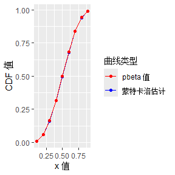

```r
ggplot(df, aes(x = x)) +
  geom_line(aes(y = as.numeric(monte_carlo), color = "蒙特卡洛估计")) +
  geom_line(aes(y = as.numeric(pbeta), color = "pbeta 值")) +
  geom_point(aes(y = as.numeric(monte_carlo), color = "蒙特卡洛估计")) +
  geom_point(aes(y = as.numeric(pbeta), color = "pbeta 值")) +
  labs(x = "x 值", y = "CDF 值", color = "曲线类型") +
  scale_color_manual(values = c("蒙特卡洛估计" = "blue", "pbeta 值" = "red"))
```

# Question 5.9

The Rayleigh density is

$$f(x)=\frac
x{\sigma^2}\:e^{-x^2/(2\sigma^2)},\quad
x\geq0,\:\sigma>0.$$

Implement a function to generate samples from a Rayleigh($\sigma)$ distribution, using antithetic variables. What is the percent reduction in variance of $\frac{X+X^{\prime}}2$ compared with $\frac{X_1+X_2}2$ for independent $X_1,X_2$?

## Answer to 5.9

- 对偶变量法采样

```r
sigma <- 1
n <- 1e4
```

- 想法是先生成 $n$ 个 $X$，再生成对偶的 $n$ 个 $X^\prime$, 最后得到$n$个样本的

$$\text{Sample_antithetic}=\frac{X+X'}2$$

```r
# Implement a function to generate samples from a Rayleigh($\sigma)$ distribution, using antithetic variables.
antithetic_rayleigh <- function(sigma, n) {
  u <- runif(n)
  X <- sigma * sqrt(-2 * log(u))
  X_prime <- sigma * sqrt(-2 * log(1 - u))
  return((X + X_prime) / 2)
}

# 对偶变量法采样
Sample_antithetic <- antithetic_rayleigh(sigma, n)
var_antithetic <- var(Sample_antithetic)
```

- 独立采样
  - 想法是独立生成$n$个$X_1$和$n$个$X_2$，得到$n$个样本的

$$\text{Sample_independent}=\frac{X_1+X_2}2$$

```r
# 生成瑞利分布样本的函数(上次作业)
rayleigh <- function(sigma, n) {
  U <- runif(n)
  return(sigma * sqrt(-2 * log(U)))
}

# 独立采样
X_1 <- rayleigh(sigma, n)
X_2 <- rayleigh(sigma, n)
Sample_independent <- (X_1 + X_2) / 2
var_independent <- var(Sample_independent)
```

- 计算percent reduction in variance

```r
reduced_percentage <- (var_independent - var_antithetic) / var_independent * 100
cat("对于参数 sigma =", sigma, "和样本数量 n =", n, "\n")
```

```
## 对于参数 sigma = 1 和样本数量 n = 10000
```

```r
cat("独立采样的样本方差为", var_independent, "\n")
```

```
## 独立采样的样本方差为 0.2090716
```

```r
cat("对偶变量法采样的样本方差为", var_antithetic, "\n")
```

```
## 对偶变量法采样的样本方差为 0.01129598
```

```r
cat("方差减少的百分比为：", reduced_percentage, "%\n")
```

```
## 方差减少的百分比为： 94.59708 %
```

# Question 5.13

Find two importance functions $f_1$ and $f_2$ that are supported on $(1,\infty)$ and are `close’ to
$$g(x)=\frac{x^2}{\sqrt{2\pi}}\:e^{-x^2/2},\quad
x>1.$$
Which of your two importance functions should produce the smaller variance in estimating
$$\int_1^\infty\frac{x^2}{\sqrt{2\pi}}\:e^{-x^2/2}\:dx$$
by importance sampling? Explain.

## Answer to 5.13

以下是用 R Markdown 解决这个问题的步骤：

- 首先定义目标函数 $g(x)$：

```r
g <- function(x) {
  ifelse(x > 1, x ^ 2 / sqrt(2 * pi) * exp(-x ^ 2 / 2), 0)
}
```

- 定义$f_1$ 和 $f_2$：
  $$f_1=e^{-(x-1)},\quad x>1.$$
  $$f_2=2e^{-2(x-1)},\quad x>1.$$
  由于
  $$\int_{1}^{\infty}e^{-(x-1)}dx=1$$
  $$\int_{1}^{\infty}2e^{-2(x-1)}dx=1$$
  它们是$(1,\infty)$上的pdf

```r
f1 <- function(x) {
  ifelse(x > 1, exp(-(x - 1)), 0)
}
f2 <- function(x) {
  ifelse(x > 1, 2 * exp(-2 * (x - 1)), 0)
}
```

- 绘制函数图像
  - 使用 `ggplot2` 包绘制 $g(x)$、$f_1(x)$ 和 $f_2(x)$ 在 $(1,\infty)$ 上的图像：

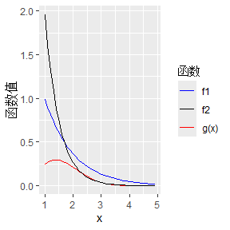

```r
# 生成数据
set.seed(12345)
x <- seq(1.01, 5, by = 0.1)
data <- data.frame(
  x = x,
  g = g(x),
  f1 = f1(x),
  f2 = f2(x)
)

# 绘制图像
ggplot(data, aes(x = x)) +
  geom_line(aes(y = g, color = "g(x)")) +
  geom_line(aes(y = f1, color = "f1")) +
  geom_line(aes(y = f2, color = "f2")) +
  labs(x = "x", y = "函数值", color = "函数") +
  scale_color_manual(values = c(
    "g(x)" = "red",
    "f1" = "blue",
    "f2" = "black"
  ))
```

- 分析方差

```r
m <- 1e4
# Importance sampling for f1
samples1 <- rexp(m, 1) + 1
gf1 <- g(samples1) / f1(samples1)
var1 <- var(gf1)

# Importance sampling for f2
samples2 <- rexp(m, 2) + 1
gf2 <- g(samples2) / f1(samples2)
var2 <- var(gf2)

# 打印结果
cat("f1在估计积分时产生的方差为：", var1, "\n")
```

```
## f1在估计积分时产生的方差为： 0.02515334
```

```r
cat("f2在估计积分时产生的方差为：", var2, "\n")
```

```
## f2在估计积分时产生的方差为： 0.01319606
```

```r
# Determine which variance is smaller
if (var1 < var2) {
  cat("f1在估计积分时产生的方差更小")
} else {
  cat("f2在估计积分时产生的方差更小")
}
```

```
## f2在估计积分时产生的方差更小
```

# Question Monte Carlo experiment

- For $n = 10^4 ,2 × 10^4 ,4 × 10^4 ,6 × 10^4 ,8 × 10^4$ , apply the fast sorting algorithm to randomly permuted numbers of $1,...,n$.
- Calculate computation time averaged over 100 simulations, denoted by $a_n$.
- Regress $a_n$ on $t_n := nlog(n)$, and graphically show the results (scatter plot and regression line).

## Answer

- 定义快速排序函数

```r
qsort <- function(x) {
  if (length(x) <= 1)
    return(x)
  pivot <- x[sample(length(x), 1)]
  left <- x[x < pivot]
  right <- x[x > pivot]
  return(c(qsort(left), pivot, qsort(right)))
}
```

- 进行模拟并计算平均时间

```r
set.seed(12345)
n_values <- c(1 * 10 ^ 4, 2 * 10 ^ 4, 4 * 10 ^ 4, 6 * 10 ^ 4, 8 * 10 ^ 4)
m <- 100 #  100 simulations
times <- numeric(length(n_values))

for (i in seq_along(n_values)) {
  n <- n_values[i]
  total_time <- 0
  for (j in 1:m) {
    x <- 1:n
    start_time <- Sys.time()
    qsort(x)
    end_time <- Sys.time()
    total_time <- total_time + as.numeric(difftime(end_time, start_time, units = "secs"))
  }
  times[i] <- total_time / m
}
```

- 计算并进行回归

```r
t_values <- n_values * log(n_values)
time_fit <- lm(times ~ t_values)
summary(time_fit)
```

[output not shown]

- 绘制散点图和回归线

```r
ggplot(data = data.frame(n = n_values, times = times, t = t_values), aes(x = t, y = times)) + geom_point() +
  geom_smooth(method = "lm", se = FALSE) + labs(x = "nlog(n)", y = "平均计算时间")
```

[output not shown]

# Question 6.6

Estimate the $0.025,0.05,0.95$, and $0.975$ quantiles of the skewness $\sqrt b_1$ under normality by a Monte Carlo experiment. Compute the standard error of the estimates from the variance of the $q$ sample quantile
$$Var(\hat{x}_q)=\frac{q(1-q)}{nf(x_q)^2},$$
where $f$ is the density of the sampled distribution, using the normal approximation for the density (with exact variance formula). Compare the estimated quantiles with the quantiles of the large sample approximation $\sqrt b_1\approx N(0,6/n).$

## Answer to 6.6

- 定义计算偏度的函数

```r
set.seed(12345)
skewness <- function(x) {
  n <- length(x)
  mean_x <- mean(x)
  std_dev <- sd(x)
  m3 <- sum((x - mean_x) ^ 3) / n
  return(m3 / std_dev ^ 3)
}
```

- MC模拟并计算分位数和标准误差

```r
n <- 1000
m <- 1e4

skewness_values <- numeric(m)
for (i in 1:m) {
  x <- rnorm(n)
  skewness_values[i] <- skewness(x)
}

# 计算分位数和标准误差
quantiles <- c(0.025, 0.05, 0.95, 0.975)
estimated_quantiles <- quantile(skewness_values, quantiles)

density <- dnorm(estimated_quantiles)
var <- quantiles * (1 - quantiles) / (n * density ^ 2)
se <- sqrt(var)
```

- 计算大样本近似的分位数

```r
large_sample_quantiles <- qnorm(quantiles, mean = 0, sd = sqrt(6 / n))
```

- 比较结果

```r
results <- data.frame(
  分位数 = quantiles,
  标准差 = se,
  估计分位数 = estimated_quantiles,
  大样本分位数 = large_sample_quantiles
)

print(results)
```

```
##       分位数     标准差 估计分位数 大样本分位数
## 2.5%   0.025 0.01251513 -0.1498065   -0.1518182
## 5%     0.050 0.01741288 -0.1257532   -0.1274098
## 95%    0.950 0.01741282  0.1257233    0.1274098
## 97.5%  0.975 0.01252137  0.1530960    0.1518182
```

# Question 6.B

Tests for association based on Pearson product moment correlation $\rho$, Spearman’s rank correlation coefficient $\rho_s$, or Kendall’s coefficient $\tau$, are implemented in cor.test. Show (empirically) that the nonparametric tests based on $\rho_s$ or $\tau$ are less powerful than the correlation test when the sampled distribution is bivariate normal. Find an example of an alternative (a bivariate distribution $(X,Y)$ such that $X$ and $Y$ are dependent) such that at least one of the nonparametric tests have better empirical power than the correlation test against this alternative.

## Answer to 6.B

- 生成二元正态分布数据并进行检验的函数

```r
bivariate_normal_test <- function(n, m) {
  p_values_Pearson <- rep(NA, m)
  p_values_spearman <- rep(NA, m)
  p_values_kendall <- rep(NA, m)
  for (i in 1:m) {
    x <- rnorm(n)
    y <- rnorm(n)
    cor_res <- cor.test(x, y)
    p_values_Pearson[i] <- cor_res$p.value
    spearman_res <- cor.test(x, y, method = 'spearman')
    p_values_spearman[i] <- spearman_res$p.value
    kendall_res <- cor.test(x, y, method = 'kendall')
    p_values_kendall[i] <- kendall_res$p.value
  }
  list(
    p_values_Pearson = p_values_Pearson,
    p_values_spearman = p_values_spearman,
    p_values_kendall = p_values_kendall
  )
}
```

- 计算功效的函数

```r
compute_power <- function(p_values) {
  mean(p_values < 0.05)
}
```

- 定义函数：输出二元正态分布下的检验功效

```r
print_power_bivariate_normal <- function(n, m) {
  test_results <- bivariate_normal_test(n, m)
  power_Pearson <- compute_power(test_results$p_values_Pearson)
  power_spearman <- compute_power(test_results$p_values_spearman)
  power_kendall <- compute_power(test_results$p_values_kendall)
  cat('在二元正态分布下，样本量为', n, '，重复次数为', m, '时：\n')
  cat('Pearson相关检验的功效：', power_Pearson, '\n')
  cat('Spearman检验的功效：', power_spearman, '\n')
  cat('Kendall检验的功效：', power_kendall, '\n')
}
```

- 非正态分布的例子：指数分布

```r
# 生成基于指数分布的数据并进行检验的函数
exponential_test <- function(n, m) {
  p_values_Pearson <- rep(NA, m)
  p_values_spearman <- rep(NA, m)
  p_values_kendall <- rep(NA, m)
  for (i in 1:m) {
    x <- rexp(n)
    y <- rexp(n)
    cor_res <- cor.test(x, y)
    p_values_Pearson[i] <- cor_res$p.value
    spearman_res <- cor.test(x, y, method = 'spearman')
    p_values_spearman[i] <- spearman_res$p.value
    kendall_res <- cor.test(x, y, method = 'kendall')
    p_values_kendall[i] <- kendall_res$p.value
  }
  list(
    p_values_Pearson = p_values_Pearson,
    p_values_spearman = p_values_spearman,
    p_values_kendall = p_values_kendall
  )
}
```

- 定义函数：输出非二元正态分布下的检验功效

```r
print_power_exponential <- function(n, m) {
  test_results <- exponential_test(n, m)
  power_Pearson <- compute_power(test_results$p_values_Pearson)
  power_spearman <- compute_power(test_results$p_values_spearman)
  power_kendall <- compute_power(test_results$p_values_kendall)
  cat('在非正态分布下，样本量为', n, '，重复次数为', m, '时：\n')
  cat('Pearson相关检验的功效：', power_Pearson, '\n')
  cat('Spearman检验的功效：', power_spearman, '\n')
  cat('Kendall检验的功效：', power_kendall, '\n')
}
```

- 报告结论

```r
set.seed(12345)
n <- 100
m <- 1000
print_power_bivariate_normal(n, m)# 二元正态分布
```

```
## 在二元正态分布下，样本量为 100 ，重复次数为 1000 时：
## Pearson相关检验的功效： 0.054
## Spearman检验的功效： 0.051
## Kendall检验的功效： 0.048
```

```r
cat('\n')
```

```r
print_power_exponential(n, m)# 非正态分布
```

```
## 在非正态分布下，样本量为 100 ，重复次数为 1000 时：
## Pearson相关检验的功效： 0.047
## Spearman检验的功效： 0.048
## Kendall检验的功效： 0.046
```

# Question on PPT

If we obtain the powers for two methods under a particular simulation setting with $10,000$ experiments: say, $0.651$ for one method and $0.676$ for another method. We want to know if the powers are different at $0.05$ level. - What is the corresponding hypothesis test problem? - What test should we use? Z-test, two-sample t-test, paired-t test or McNemar test? Why? - Please provide the least necessary information for hypothesis testing.

## Answer

- What is the corresponding hypothesis test problem?
  $$H_0: p_1 = p_2 \longleftrightarrow H_1: p_1 \neq
  p_2$$
- What test should we use?
  - 应使用 Z 检验
  - 因为这是对两个独立样本比例的比较，样本量较大（10,000 次实验），符合 Z 检验的条件
- Provide the least necessary information for hypothesis testing
  - 两种方法的功效估计值（$\hat p_1=0.651$ 和 $\hat p_2=0.676$）
  - 样本量（10,000 次实验）
  - 显著性水平（0.05）

```r
# 计算 Z 统计量
p1 <- 0.651
p2 <- 0.676
n <- 10000
se1 <- sqrt(p1 * (1 - p1) / n)
se2 <- sqrt(p2 * (1 - p2) / n)
se <- sqrt(se1 ^ 2 + se2 ^ 2)
z <- (p2 - p1) / se
# 计算 P 值
p_value <- 2 * pnorm(-abs(z))

# 判断是否拒绝零假设
cat('p=', p_value,'\n')
```

```
## p= 0.0001821846
```

```r
if (p_value < 0.05) {
  cat("在 0.05 水平上，两种方法的功效有显著差异。\n")
} else {
  cat("在 0.05 水平上，两种方法的功效没有显著差异。\n")
}
```

```
## 在 0.05 水平上，两种方法的功效有显著差异。
```

# Question

Of N =1000 hypotheses, 950 are null and 50 are alternative. The p-value under any null hypothesis is uniformly distributed (use runif), and the p-value under any alternative hypothesis follows the beta distribution with parameter 0.1 and 1 (use rbeta). Obtain Bonferroni adjusted p-values and B-H adjusted p-values. Calculate FWER, FDR, and TPR under nominal level $\alpha =0.1$ for each of the two adjustment methods based on m=10000 simulation replicates. You should output the 6 numbers (3) to a 3×2 table (column names: Bonferroni correction, B-H correction; row names: FWER, FDR, TPR). Comment the results.

## Answer

```r
set.seed(123)
N <- 1000
n0 <- 950
n1 <- 50
m <- 10000
alpha <- 0.1

# 循环生成模拟的 p 值
p_values <- matrix(NA, nrow = m, ncol = N)
for (i in 1:m) {
  for (j in 1:N) {
    if (j <= n0) {
      p_values[i, j] <- runif(1)
    } else {
      p_values[i, j] <- rbeta(1, 0.1, 1)
    }
  }
}

# 调整后的 p 值
p_bonferroni <- p_values * N
p_bh <- matrix(NA, nrow = m, ncol = N)
for (i in 1:m) {
  sorted_p <- sort(p_values[i, ])
  for (j in 1:N) {
    p_bh[i, j] <- sorted_p[j] * N / (j)
  }
}

# 计算
FWER_bonferroni <- mean(rowSums(p_bonferroni <= alpha) > 0)
FDR_bonferroni <- mean(apply(p_bonferroni <= alpha, 1, function(x)
  mean(p_values[x, ] <= alpha / N)))
TPR_bonferroni <- mean(apply(p_bonferroni <= alpha, 1, function(x)
  mean(p_values[x, (n0 + 1):N] <= alpha / N)))

FWER_bh <- mean(rowSums(p_bh <= alpha) > 0)
FDR_bh <- mean(apply(p_bh <= alpha, 1, function(x)
  mean(p_values[x, ] <= alpha / N)))
TPR_bh <- mean(apply(p_bh <= alpha, 1, function(x)
  mean(p_values[x, (n0 + 1):N] <= alpha / N)))

# 结果
result <- matrix(
  c(FWER_bonferroni, FWER_bh, FDR_bonferroni, FDR_bh, TPR_bonferroni, TPR_bh),
  nrow = 3,
  ncol = 2,
  byrow = FALSE
)
colnames(result) <- c("Bonferroni correction", "B-H correction")
rownames(result) <- c("FWER", "FDR", "TPR")
result
```

[output not shown]

- Bonferroni 校正结果分析
  - FWER：Bonferroni 校正后的 FWER 为1.0000000，这意味着在所有模拟中，几乎每次都至少错误地拒绝了一个零假设。这表明 Bonferroni 校正可能过于保守，导致在控制整体错误率时过于严格，使得即使在没有真正效应的情况下，也很容易拒绝零假设。
  - FDR：FDR 为 1.0000000，说明在被拒绝的假设中，几乎所有都是错误的发现。这进一步说明了 Bonferroni 校正的保守性，它可能将很多实际上可能为真的备择假设也判定为错误，从而导致错误发现率极高。
  - TPR：TPR 为 0.0198133，非常低。这意味正确拒绝零假设找到备择假设为真的情况很少被检测到。Bonferroni 校正的严格性使得它在控制错误率的同时，牺牲了对真正效应的检测能力。
- B - H 校正结果分析
  - FWER：B - H 校正后的 FWER 为 0.01989188，相对 Bonferroni 校正要低很多，说明 B - H 校正能够较好地控制整体错误率，不会像 Bonferroni 校正那样过于频繁地错误拒绝零假设。
  - FDR：FDR 为 0.39458600，虽然不是很低，但相比于 Bonferroni 校正的 1.0000000 有了很大改善。这表明 B - H 校正能够在一定程度上控制错误发现率，在允许一些错误发现的同时，也能找到一些真正的效应。
  - TPR：TPR 为 0.39633916，相对 Bonferroni 校正的结果要高很多。这说明 B - H 校正能够更好地检测到备择假设为真的情况，在控制错误率的同时，保持了对真正效应的一定检测能力。 总体而言，Bonferroni 校正过于保守，虽然严格控制了错误率，但牺牲了对真正效应的检测能力；而 B - H 校正相对更为合理，在控制错误率和检测真正效应之间取得了较好的平衡。

# Question 7.4

Refer to the air-conditioning data set `aircondit` provided in the boot package. The 12 observations are the times in hours between failures of air-conditioning equipment:
$$3,5,7,18,43,85,91,98,100,130,230,487.$$
Assume that the times between failures follow an exponential model Exp$(\lambda)$. Obtain the MLE of the hazard rate $\lambda$ and use bootstrap to estimate the bias and standard error of the estimate.

## Answer to 7.4

指数分布的概率密度函数为
$$f(x)=\lambda
e^{-\lambda x}$$
其中 $x\geq0$，$\lambda>0$。对于一组独立同分布的样本 $x_1,x_2,\cdots,x_n$，其似然函数为
$$L(\lambda)=\prod_{i=1}^{n}\lambda
e^{-\lambda x_i}=\lambda^n exp\{-\lambda\sum_{i=1}^{n}x_i\}$$
对数似然函数为
$$l(\lambda)=n\log(\lambda)-\lambda\sum_{i=1}^{n}x_i$$
对对数似然函数求导并令其为 0，可得：
$$\frac{\partial
l(\lambda)}{\partial\lambda}=\frac{n}{\lambda}-\sum_{i=1}^{n}x_i=0$$
解出极大似然估计值
$$\hat{\lambda}=\frac{n}{\sum_{i=1}^{n}x_i}$$

```r
times <- c(3, 5, 7, 18, 43, 85, 91, 98, 100, 130, 230, 487)
# 危险率lambda的极大似然估计值
n <- length(times)
lambda_hat <- n/sum(times)
cat("MLE of the hazard rate lambda：", lambda_hat, "\n")
```

```
## MLE of the hazard rate lambda： 0.00925212
```

```r
set.seed(123)
# Bootstrap
B <- 1000 # 设置自助抽样次数
lambda_boot <- numeric(B)
for (i in 1:B) {
  boot_sample <- sample(times, replace = TRUE)
  lambda_boot[i] <- length(boot_sample)/sum(boot_sample)
}

bias <- mean(lambda_boot) - lambda_hat
se <- sd(lambda_boot)

cat("Bias:", bias, "\n")
```

```
## Bias: 0.001582967
```

```r
cat("Standard error:", se)
```

```
## Standard error: 0.004452266
```

# Question 7.5

Refer to Exercise 7.4. Compute 95% bootstrap confidence intervals for the mean time between failures $1/\lambda$ by the standard normal, basic, percentile, and BCa methods. Compare the intervals and explain why they may differ.

## Answer to 7.5

```r
set.seed(123)
# 计算平均故障间隔时间
mean_time <- 1/lambda_hat

# 计算 95%置信区间
## 标准正态方法
z <- qnorm(0.975)
normal_interval <- mean_time + c(-z * se, z * se) * (1/lambda_hat^2)

## 基本方法
basic_interval <- quantile(lambda_boot, c(0.025, 0.975))
basic_interval <- 1/basic_interval

## 百分位数方法
percentile_interval <- quantile(1/lambda_boot, c(0.025, 0.975))

## BCa方法
boot_obj <- boot(data = times, statistic = function(x, i) {
  n <- length(x[i])
  return(n/sum(x[i]))
}, R = B)
bca_interval <- boot.ci(boot_obj, type = "bca")$bca[4:5]
bca_interval <- 1/bca_interval

cat("标准正态法 95%置信区间：[", normal_interval[1], ",", normal_interval[2], "]\n")
```

```
## 标准正态法 95%置信区间：[ 6.142867 , 210.0238 ]
```

```r
cat("基本方法 95%置信区间：[", basic_interval[2], ",", basic_interval[1], "]\n")
```

```
## 基本方法 95%置信区间：[ 47.39331 , 193.5167 ]
```

```r
cat("分位数法 95%置信区间：[", percentile_interval[1], ",", percentile_interval[2], "]\n")
```

```
## 分位数法 95%置信区间：[ 47.39375 , 193.5187 ]
```

```r
cat("BCa法 95%置信区间：[", bca_interval[2], ",", bca_interval[1], "]\n")
```

```
## BCa法 95%置信区间：[ 56.25 , 212.0832 ]
```

- 不同方法计算的置信区间可能不同的原因主要有以下几点：
  - 标准正态法基于大样本理论和正态分布假设，对数据分布有较强的要求。如果数据不满足正态分布，该方法的准确性可能受到影响。
  - 基本方法和分位数法相对简单直接，但对抽样分布的形状假设较少，可能在样本量较小时不够准确。
  - BCa 方法通过调整百分位数方法，考虑了估计量的偏度和抽样分布的不对称性，通常在各种情况下更加准确和稳健。

# Question 7.8

Refer to Exercise 7.7. Obtain the jackknife estimates of bias and standard error of $\hat\theta$.

## Answer to 7.8

```r
sc<-scor
set.seed(123)

# 计算theta的函数
estimate_theta <- function(x) {
    cov(x) %>%
    prcomp() %>%
    {.$sdev[1]/sum(.$sdev)}
}

n<-nrow(sc)
theta.j<- numeric(n)
for (i in 1:n){
  theta.j[i]<-estimate_theta(sc[-i,])
}
theta.hat<-estimate_theta(sc)

bias<-(n-1)*(mean(theta.j)-theta.hat) #BIAS
se<-sqrt((n-1)*var(theta.j)) #SE

cat("Bias:", round(bias,3), "\n")
```

```
## Bias: 0.014
```

```r
cat("standard error:", round(se,3),"\n")
```

```
## standard error: 0.053
```

# Question 7.10

In Example 7.18, leave-one-out $(n$-fold) cross validation was used to select the best fitting model. Repeat the analysis replacing the Log-Log model with a cubic polynomial model. Which of the four models is selected by the cross validation procedure? Which model is selected according to maximum adjusted $R^2?$

## Answer to 7.10

```r
attach(ironslag)
n <- length(magnetic) #in DAAG ironslag
e1 <- e2 <- e3 <- e4 <- numeric(n)

# for n-fold cross validation
# fit models on leave-one-out samples
for (k in 1:n) {
  y <- magnetic[-k]
  x <- chemical[-k]
  J1 <- lm(y ~ x)
  yhat1 <- J1$coef[1] + J1$coef[2] * chemical[k]
  e1[k] <- magnetic[k] - yhat1

  J2 <- lm(y ~ x + I(x^2))
  yhat2 <- J2$coef[1] + J2$coef[2] * chemical[k] +
    J2$coef[3] * chemical[k]^2
  e2[k] <- magnetic[k] - yhat2

  J3 <- lm(log(y) ~ x)
  logyhat3 <- J3$coef[1] + J3$coef[2] * chemical[k]
  yhat3 <- exp(logyhat3)
  e3[k] <- magnetic[k] - yhat3

  J4 <- lm(y ~ x + I(x^2)+I(x^3))
  yhat4 <- J4$coef[1] + J4$coef[2] * chemical[k] +J4$coef[3] * chemical[k]^2 +J4$coef[3] * chemical[k]^3
  e4[k] <- magnetic[k] - yhat4
}

round(c(mean(e1^2), mean(e2^2), mean(e3^2), mean(e4^2)),3)
```

```
## [1]      19.556      17.852      18.442 2155967.354
```

CV表明，选择二次模型

```r
# 函数：拟合模型，返回模型列表
fit_models <- function(y, x) {
  L1 <- lm(y ~ x)
  L2 <- lm(y ~ x + I(x ^ 2))
  L3 <- lm(log(y) ~ x)
  L4 <- lm(y ~ x + I(x ^ 2) + I(x ^ 3))
  return(list(L1, L2, L3, L4))
}

# maximum adjusted R^2 选择模型
fit_models(magnetic, chemical) %>%
  sapply(., function(model)
    round(summary(model)$adj.r.squared, 3)) %>%
  cat("Adjusted-R^2:\n", .)
```

```
## Adjusted-R^2:
##  0.528 0.577 0.528 0.574
```

adjust-R^2表明，选择二次模型

# Question 8.1

Implement the two-sample Cramer-von Mises test for equal distributions as a permutation test. Apply the test to the data in Examples 8.1 and 8.2.

## Answer to 8.1

```r
# 计算 Cramer-von Mises 统计量
cvm_stat <- function(x, y) {
  n <- length(x)
  m <- length(y)
  Fn <- ecdf(x)
  Gm <- ecdf(y)
  term1 <- sum((Fn(x) - Gm(x)) ^ 2)
  term2 <- sum((Fn(y) - Gm(y)) ^ 2)
  return((m * n) / (m + n) ^ 2 * (term1 + term2))
}

# 置换检验函数
permutation_test <- function(x, y, B = 1000) {
  observed_stat <- cvm_stat(x, y)
  z <- c(x, y)
  n <- length(x)
  m <- length(y)
  stats <- numeric(B)
  for (i in 1:B) {
    permuted <- sample(z)
    x_perm <- permuted[1:n]
    y_perm <- permuted[(n + 1):(n + m)]
    stats[i] <- cvm_stat(x_perm, y_perm)
  }
  p_value <- mean(stats >= observed_stat)
  return(list(observed_statistic = observed_stat, p_value = p_value))
}

# 结果打印函数
print_permutation_test_result <- function(x, y) {
  set.seed(123)
  permutation_test(x, y)$observed_statistic %>%
    cat("Observed Cramer-von Mises statistic:", ., "\n")
  p_value <- permutation_test(x, y)$p_value
  cat("P-value:", p_value, "\n")
  if (p_value < 0.05)
    cat("p < 0.05，拒绝原假设。\n")
  else
    cat("p > 0.05，不能拒绝原假设\n")
}
```

- Examples 8.1 and 8.2

```r
# 数据
attach(chickwts)
eg_x <- sort(as.vector(weight[feed == "soybean"]))
eg_y <- sort(as.vector(weight[feed == "linseed"]))

print_permutation_test_result(eg_x, eg_y)
```

```
## Observed Cramer-von Mises statistic: 0.1515216
## P-value: 0.394
## p > 0.05，不能拒绝原假设
```

基于本次 Cramer-von Mises 检验的结果，不能得出示例中的两个样本（大豆组和亚麻籽组的小鸡体重数据）来自不同分布的结论，即可以认为这两个组的小鸡体重分布可能是相似的。

# Question 8.2

Implement the bivariate Spearman rank correlation test for independence [255] as a permutation test. The Spearman rank correlation test statistic can be obtained from function `cor` with `method = "spearman"`. Compare the achieved significance level of the permutation test with the p-value reported by cor.test on the same samples.

## Answer to 8.2

```r
# 置换检验函数
permutation_test_spearman <- function(x, y, B = 1000) {
  observed_stat <- cor(x, y, method = "spearman")
  n <- length(x)
  stats <- numeric(B)
  for (i in 1:B) {
    permuted_y <- sample(y)
    stats[i] <- cor(x, permuted_y, method = "spearman")
  }
  p_value <- mean(abs(stats) >= abs(observed_stat))
  return(list(observed_statistic = observed_stat, p_value = p_value))
}

# 生成随机数据
set.seed(123)
x <- rnorm(1e3)
y <- rnorm(1e3)

perm_result <- permutation_test_spearman(x, y)
cor_test_result <- cor.test(x, y, method = "spearman")

# 结果打印
round(perm_result$observed_statistic, 3) %>%
  cat("Observed Spearman correlation statistic from permutation test:",
      .,
      "\n")
```

```
## Observed Spearman correlation statistic from permutation test: 0.081
```

```r
round(perm_result$p_value, 3) %>%
  cat("P-value from permutation test:", ., "\n")
```

```
## P-value from permutation test: 0.005
```

```r
round(cor_test_result$p.value, 3) %>%
  cat("P-value from cor.test:", ., "\n")
```

```
## P-value from cor.test: 0.01
```

# Question 9.3

Use the Metropolis-Hastings sampler to generate random variables from a standard Cauchy distribution. Discard the first 1000 of the chain, and compare the deciles of the generated observations with the deciles of the standard Cauchy distribution (see `qcauchy` or `qt` with $df=1$). Recall that a Cauchy$(\theta,\eta)$ distribution has density function

$$f(x)=\frac1{\theta\pi(1+[(x-\eta)/\theta]^2)},\quad-\infty<x<\infty,\:\theta>0.$$

The standard Cauchy has the Cauchy$(\theta=1,\eta=0)$ density. (Note that the standard Cauchy density is equal to the Student t density with one degree of freedom.)

## Answer to 9.3

```r
set.seed(123)

# 目标密度函数（标准柯西分布）
target_density <- function(x) {
  return(1 / (pi * (1 + x^2)))
}

# Metropolis-Hastings
metropolis_hastings <- function(start_value, iterations) {
  samples <- numeric(iterations)
  current <- start_value
  for (i in 1:iterations) {
    proposal <- rnorm(1, current, 1)
    acceptance_ratio <- target_density(proposal) / target_density(current)
    if (runif(1) < acceptance_ratio) {
      current <- proposal
    }
    samples[i] <- current
  }
  return(mcmc(samples))
}

# Metropolis-Hastings并监测收敛
run_and_monitor <- function() {
  n_chains <- 2
  chain_length <- 10000
  chains <- list()
  for (i in 1:n_chains) {
    chains[[i]] <- metropolis_hastings(rnorm(1), chain_length)
  }
  combined_chains <- mcmc.list(chains)
  gelman_rubin <- gelman.diag(combined_chains, multivariate = FALSE)$psrf[1]
  while (gelman_rubin > 1.2) {
    new_chains <- list()
    for (i in 1:n_chains) {
      new_chains[[i]] <- c(chains[[i]], metropolis_hastings(chains[[i]][length(chains[[i]])], chain_length))
    }
    chains <- new_chains
    combined_chains <- mcmc.list(chains)
    gelman_rubin <- gelman.diag(combined_chains, multivariate = FALSE)$psrf[1]
  }
  return(chains)
}

# 结果输出
chains <- run_and_monitor()
all_samples <- unlist(chains)
trimmed_samples <- all_samples[-(1:1000)]
generated_deciles <- quantile(trimmed_samples, probs = seq(0.1, 0.9, by = 0.1))
true_deciles <- qcauchy(p = seq(0.1, 0.9, by = 0.1))
cat("生成的观测值十分位数：", generated_deciles, "\n")
```

```
## 生成的观测值十分位数： -12.42122 -2.73033 -1.203038 -0.5718276 -0.1638357 0.1920756 0.5787829 1.151329 2.837363
```

```r
cat("标准柯西分布十分位数：", true_deciles, "\n")
```

```
## 标准柯西分布十分位数： -3.077684 -1.376382 -0.7265425 -0.3249197 0 0.3249197 0.7265425 1.376382 3.077684
```

# Question 9.8

Consider the bivariate density
$$f(x,y)\propto\binom{n}{x}y^{x+a-1}(1-y)^{n-x+b-1},\quad
x=0,1,\ldots,n,\:0\leq y\leq1.$$

It can be shown that for fixed $a,b,n$, the conditional distributions are Binomial$(n,y)$ and Beta$(x+a,n-x+b).$ Use the Gibbs sampler to generate a chain with target joint density $f(x,y).$

## Answer to 9.8

```r
df <- function(x, y) {
  # 一般二项式系数
  gamma(n + 1) / (gamma(x + 1) * gamma(n - x + 1)) * y ^ (x + a - 1) * (1 - y) ^
    (n - x + b - 1)
}

# Gibbs 采样函数
gibbs_sampler <- function(niter = 10000) {
  d <- 2
  x1 <- matrix(0, nrow = niter, ncol = d)
  x2 <- matrix(0.1, nrow = niter, ncol = d)

  for (i in 2:niter) {
    x1[i, ] <- x1[i - 1, ] %>% {
     .[1] <- rbinom(1, n,.[2])
     .[2] <- rbeta(1,.[1] + a, n -.[1] + b)
     .
    }
    x2[i, ] <- x2[i - 1, ] %>% {
     .[1] <- rbinom(1, n,.[2])
     .[2] <- rbeta(1,.[1] + a, n -.[1] + b)
     .
    }
  }
  chain1 <- as.mcmc(x1)
  chain2 <- as.mcmc(x2)
  return(mcmc.list(chain1, chain2))
}

# 结果
set.seed(123)
n <- 100
a <- 2
b <- 3
converged <- FALSE
while (!converged) {
  combined_chain <- gibbs_sampler() %>% gelman.diag()
  if (combined_chain$mpsrf[1] < 1.2) {
    converged <- TRUE
  } else {
    combined_chain <- gibbs_sampler()
  }
}
cat("Gibbs 采样收敛情况：", converged, "\n")
```

```
## Gibbs 采样收敛情况： TRUE
```

```r
cat("目标联合密度函数中的参数 n =", n, ", a =", a, ", b =", b, "\n")
```

```
## 目标联合密度函数中的参数 n = 100 , a = 2 , b = 3
```

```r
cat("生成的马尔可夫链中前几个样本点（x,y）：\n")
```

```
## 生成的马尔可夫链中前几个样本点（x,y）：
```

```r
head(combined_chain[[1]])
```

```
##      Point est. Upper C.I.
## [1,]   1.008135   1.011828
## [2,]   1.007991   1.011209
```

# Proof the Stationarity of Metropolis-Hastings sampler Algorithm in continuous situation.

## Answer

- 当$s = r$时：
  $$K(s,r)f(s)=[1-\int\alpha(r,s)g(s|r)]f(s)$$
  $$K(r,s)f(r)=[1-\int\alpha(s,r)g(r|s)]f(r)$$
  由
  $$\alpha(s,r)=\min\{\frac{f(r)g(s|r)}{f(s)g(r|s)},1\},\quad\alpha(r,s)=\min\{\frac{f(s)g(r|s)}{f(r)g(s|r)},1\}$$
  $$\int\alpha(r,s)g(s|r)=\int\alpha(s,r)g(r|s)$$
  则
  $$K(s,r)f(s)=K(r,s)f(r)$$
- 当$s\neq r$时：
  $$K(s,r)f(s)=\alpha(s,r)g(r|s)f(s)$$
  $$K(r,s)f(r)=\alpha(r,s)g(s|r)f(r)$$
  由
  $$\alpha(s,r)=\min\{\frac{f(r)g(s|r)}{f(s)g(r|s)},1\},\quad\alpha(r,s)=\min\{\frac{f(s)g(r|s)}{f(r)g(s|r)},1\}$$
  可得：
  - 如果$\displaystyle\frac{f(r)g(s|r)}{f(s)g(r|s)}\leq1$，则
    $$\alpha(s,r)=\frac{f(r)g(s|r)}{f(s)g(r|s)},\quad\alpha(r,s)
    = 1$$
    此时
    $$K(s,r)f(s)=\frac{f(r)g(s|r)}{f(s)g(r|s)}g(r|s)f(s)=f(r)g(s|r)$$
    $$K(r,s)f(r)=g(s|r)f(r)$$
    所以
    $$K(s,r)f(s)=K(r,s)f(r)$$
  - 如果$\displaystyle\frac{f(r)g(s|r)}{f(s)g(r|s)}\gt1$，则
    $$\alpha(s,r)=1,\quad\alpha(r,s)=\frac{f(s)g(r|s)}{f(r)g(s|r)}$$
    此时
    $$K(s,r)f(s)=g(r|s)f(s)$$
    $$K(r,s)f(r)=\frac{f(s)g(r|s)}{f(r)g(s|r)}g(s|r)f(r)=g(r|s)f(s)$$
    所以
    $$K(s,r)f(s)=K(r,s)f(r)$$

综上，在连续情况下Metropolis - Hastings sampler满足平稳性$K(s,r)f(s)=K(r,s)f(r)$。

# Question 11.3

1. Write a function to compute the $k^{th}$ term in

$$\sum_{k=0}^\infty\frac{(-1)^k}{k!\:2^k}\frac{\left\|a\right\|^{2k+2}}{(2k+1)(2k+2)}\frac{\Gamma\left(\frac{d+1}{2}\right)\Gamma\left(k+\frac{3}{2}\right)}{\Gamma\left(k+\frac{d}{2}+1\right)},$$

where $d\geq1$ is an integer, $a$ is a vector in $\mathbb{R}^d$, and $\|\cdot\|$ denotes the Euclidean norm. Perform the arithmetic so that the coefficients can be computed for (almost) arbitrarily large $k$ and $d.$ (This sum converges for all $a\in\mathbb{R}^d).$

2. Modify the function so that it computes and returns the sum.
3. Evaluate the sum when $a=(1,2)^T.$

## Answer to 11.3

```r
# function to compute the kth term
compute_kth_term <- function(k, a) {
  d <- length(a)
  norm_a <- sqrt(sum(a^2))  # Euclidean norm
  term <- (-1)^k / (factorial(k) * 2^k) * (norm_a^(2*k+2)) / ((2*k+1)*(2*k+2)) *
    gamma((d+1)/2) * gamma(k + 3/2) / gamma(k + d/2 + 1)
  return(term)
}

# function to compute sum
compute_sum <- function(a, tol = 1e-10) {
  norm_a <- sqrt(sum(a^2))  # Euclidean norm
  sum_series <- 0
  k <- 0
  term <- compute_kth_term(k, a)
  while (abs(term) > tol) {
    sum_series <- sum_series + term
    k <- k + 1
    term <- compute_kth_term(k, a)
  }
  return(sum_series)
}

# Evaluate the sum when a=(1,2)
a <- c(1, 2)
result <- compute_sum(a)
cat('sum when a = (1,2) :', result)
```

```
## sum when a = (1,2) : 1.532164
```

# Question 11.5

Write a function to solve the equation

$$\begin{aligned}\frac{2\Gamma(\frac
k2)}{\sqrt{\pi(k-1)}\Gamma(\frac{k-1}2)}&\int_0^{c_{k-1}}\left(1+\frac{u^2}{k-1}\right)^{-k/2}du\\&=\frac{2\Gamma(\frac{k+1}2)}{\sqrt{\pi
k}\Gamma(\frac
k2)}\int_0^{c_k}\left(1+\frac{u^2}k\right)^{-(k+1)/2}du\end{aligned}$$

for $a$, where

$$c_k=\sqrt{\frac{a^2k}{k+1-a^2}}.$$

Compare the solutions with the points $A(k)$ in Exercise 11.4.

## Answer to 11.5

```r
# 定义方程的函数
define_equation <- function(k, a){
  int_func <- function(u, n){(1 + u^2/(n - 1))^(-n/2)}
  get_c <- function(n, a){sqrt(a^2 * n / (n + 1 - a^2))}
  expr <- function(n, a) {
    this_int_func <- function(u){
      int_func(u, n)}
    c_val <- get_c(n - 1, a)
    2/sqrt(pi*(n - 1)) * exp(lgamma(n/2)-lgamma((n - 1)/2)) *
      integrate(this_int_func, lower = 0, upper = c_val)$value}

  lhs <- expr(k, a)
  rhs <- expr(k + 1, a)
  return(lhs - rhs)
}

# 解方程的函数
solve_eq <- function(k) {
  f <- function(a){return(define_equation(k, a))}
  eps <- 1e-2
    if (f(eps) < 0 && f(sqrt(k) - eps) > 0 || f(eps) > 0 && f(sqrt(k) - eps) < 0) {
    return(uniroot(f, interval = c(eps, sqrt(k) - eps))$root)
  } else {
    return(NA)
  }
}

# 结果输出
r11.5 <- sapply(c(4:25, 100, 500, 1000), function(k) {
  solve_eq(k) %>%
    return()
})
r11.5
```

```
##  [1] 1.492073 1.533555 1.562745 1.584429 1.601184 1.614516 1.625389 1.634418
##  [9] 1.642026 1.648552 1.654175 1.659099 1.663454 1.667287       NA 1.673832
## [17] 1.676605 1.679148 1.681468 1.683593 1.685546 1.687366       NA       NA
## [25] 1.730903
```

```r
# EX 11.4
findIntersection = function (k) {
  s_k.minus.one = function (a) {1 - pt(sqrt(a ^ 2 * (k - 1) / (k - a ^ 2)), df = k - 1)}
  s_k = function (a) {1 - pt(sqrt(a ^ 2 * k / (k + 1 - a ^ 2)), df = k)}
  f = function (a) {s_k(a) - s_k.minus.one(a)}

  eps = 1e-2
  return(uniroot(f, interval = c(eps, sqrt(k) - eps))$root)
}

r11.4 <- sapply(c(4:25, 100, 500, 1000), function (k) {
  findIntersection(k)
})

r11.4
```

```
##  [1]  1.492073  1.533555  1.562745  1.584429  1.601184  1.614516  1.625389
##  [8]  1.634418  1.642026  1.648552  1.654175  1.659099  1.663454  1.667287
## [15]  1.670733  1.673832  1.676605  1.679148  1.681468  4.785832  4.888979
## [22]  4.990000  9.990000 22.350680 31.612777
```

# Question

Suppose $T_1,\ldots,T_n$ are i.i.d. samples drawn from the exponential distribution with expectation $\lambda.$ Those values greater than $\tau$ are not observed due to right censorship, so that the observed values are
$$Y_i=T_iI(T_i\leq\tau)+\tau
I(T_i>\tau)$$
$i=1,\ldots,n.$ Suppose $\tau=1$ and the observed $Y_i$ values are as follows:
$$0.54,0.48,0.33,0.43,1.00,1.00,0.91,1.00,0.21,0.85$$
Use the E-M algorithm to estimate $\lambda$, compare your result with the observed data MLE (note: $Y_i$ follows a mixture distribution).

## Answer

```r
# E步函数
E_step <- function(Y, tau, lambda0) {
  n <- length(Y)
  loglikelihood <- ifelse(Y < tau, log(lambda0) - lambda0 * Y, log(lambda0) - lambda0 * (tau + 1 / lambda0))
  return(sum(loglikelihood))
}

# M步函数
M_step <- function(Y, tau, lambda0) {
  n <- length(Y)
  expected_Ti <- ifelse(Y < tau, Y, tau + 1 / lambda0)
  return(n / sum(expected_Ti))
}

# EM算法
EM_algorithm <- function(Y, tau, lambda0) {
  while (TRUE) {
    Q_old <- E_step(Y, tau, lambda0)
    lambda1 <- M_step(Y, tau, lambda0)
    Q_new <- E_step(Y, tau, lambda1)
    # 同时考虑lambda的变化和对数似然期望的变化
    if (abs(lambda1 - lambda0) < 1e-6 && abs(Q_new - Q_old) < 1e-6) {
      break
    }
    lambda0 <- lambda1
  }
  return(lambda1)
}

# 观测数据的似然函数
loglikelihood <- function(Y, tau, lambda) {
  loglik <- ifelse(Y < tau, log((1 - exp(-lambda * tau)) * lambda * exp(-lambda * Y)), log(exp(-lambda * tau)))
  return(-sum(loglik))
}

# 结果输出
Y <- c(0.54,0.48,0.33,0.43,1.00,1.00,0.91,1.00,0.21,0.85)
tau <- 1
lambda0 <- 1

EM_algorithm(Y, tau, lambda0) %>%
  round(., 3) %>%
  cat('EM算法估计的lambda值为：', ., '\n')
```

```
## EM算法估计的lambda值为： 1.037
```

```r
result_optim <- optim(
  par = lambda0, fn = loglikelihood, method = 'BFGS', Y = Y, tau = tau)
  lambda_mle <- round(result_optim$par, 3) %>%
    cat('观测数据MLE估计的lambda值为：',., '\n')
```

```
## 观测数据MLE估计的lambda值为： 1.487
```

# Excecise 11.7 (page 354, Statistical Computing with R)

Use the simplex algorithm to solve the following problem. Minimize $4x+2y+9z$ subject to

$$\begin{aligned}&2x+y+z\leq2\\&x-y+3z\leq3\\&x\geq0,\:y\geq0,\:z\geq0.\end{aligned}$$

## Answer

```r
obj_coeffs <- c(4, 2, 9)
constraint_matrix <- matrix(c(2, 1, 1, 1, -1, 3), nrow = 2, byrow = TRUE)
rhs_constants <- c(2, 3)
constraint_directions <- c('<', '<')

solution <- lp(direction = 'min',
                objective.in = obj_coeffs,
                const.mat = constraint_matrix,
                const.dir = constraint_directions,
                const.rhs = rhs_constants)

# 输出结果
cat('目标函数的最优值为：', solution$objval,'\n')
```

```
## 目标函数的最优值为： 0
```

```r
cat('x的值为：', solution$solution[1],'\n')
```

```
## x的值为： 0
```

```r
cat('y的值为：', solution$solution[2],'\n')
```

```
## y的值为： 0
```

```r
cat('z的值为：', solution$solution[3],'\n')
```

```
## z的值为： 0
```

# Excecise 3 (page 204, Advanced R)

Use both for loops and `lapply()` to fit linear models to the **mtcars** using the formulas stored in this list:

```r
formulas <- list(
  mpg ~ disp,
  mpg ~ I(1 / disp),
  mpg ~ disp + wt,
  mpg ~ I(1 / disp) + wt
)
```

## Answer

```r
# for loops
fl_1 <- list()
for (i in 1:length(formulas)) {
  # 在每次循环中，使用当前公式拟合线性模型，并将结果存储到列表中
  fl_1[[i]] <- lm(formulas[[i]], data = mtcars)
}
fl_1
```

```
## [[1]]
##
## Call:
## lm(formula = formulas[[i]], data = mtcars)
##
## Coefficients:
## (Intercept)         disp
##    29.59985     -0.04122
##
##
## [[2]]
##
## Call:
## lm(formula = formulas[[i]], data = mtcars)
##
## Coefficients:
## (Intercept)    I(1/disp)
##       10.75      1557.67
##
##
## [[3]]
##
## Call:
## lm(formula = formulas[[i]], data = mtcars)
##
## Coefficients:
## (Intercept)         disp           wt
##    34.96055     -0.01772     -3.35083
##
##
## [[4]]
##
## Call:
## lm(formula = formulas[[i]], data = mtcars)
##
## Coefficients:
## (Intercept)    I(1/disp)           wt
##      19.024     1142.560       -1.798
```

```r
# lapply
la_1 <- lapply(formulas, lm, data = mtcars)
la_1
```

```
## [[1]]
##
## Call:
## FUN(formula = X[[i]], data = ..1)
##
## Coefficients:
## (Intercept)         disp
##    29.59985     -0.04122
##
##
## [[2]]
##
## Call:
## FUN(formula = X[[i]], data = ..1)
##
## Coefficients:
## (Intercept)    I(1/disp)
##       10.75      1557.67
##
##
## [[3]]
##
## Call:
## FUN(formula = X[[i]], data = ..1)
##
## Coefficients:
## (Intercept)         disp           wt
##    34.96055     -0.01772     -3.35083
##
##
## [[4]]
##
## Call:
## FUN(formula = X[[i]], data = ..1)
##
## Coefficients:
## (Intercept)    I(1/disp)           wt
##      19.024     1142.560       -1.798
```

# Excecise 4 (page 204, Advanced R)

Fit the model **mpg ~ disp** to each of the bootstrap replicates of **mtcars** in the list below by using a for loop and `lapply()`. Can you do it without an anonymous function?

```r
bootstraps <- lapply(1:10, function(i) {
  rows <- sample(1:nrow(mtcars), rep = TRUE)
  mtcars[rows, ]
})
```

## Answer

```r
# for loops
fl_2 <- list()
for (i in seq_along(bootstraps)) {
  fl_2[[i]] <- lm(mpg ~ disp, data = bootstraps[[i]])
}
fl_2
```

```
## [[1]]
##
## Call:
## lm(formula = mpg ~ disp, data = bootstraps[[i]])
##
## Coefficients:
## (Intercept)         disp
##    28.97694     -0.04166
##
##
## [[2]]
##
## Call:
## lm(formula = mpg ~ disp, data = bootstraps[[i]])
##
## Coefficients:
## (Intercept)         disp
##    29.70745     -0.03731
##
##
## [[3]]
##
## Call:
## lm(formula = mpg ~ disp, data = bootstraps[[i]])
##
## Coefficients:
## (Intercept)         disp
##     32.3203      -0.0493
##
##
## [[4]]
##
## Call:
## lm(formula = mpg ~ disp, data = bootstraps[[i]])
##
## Coefficients:
## (Intercept)         disp
##    29.15189     -0.03845
##
##
```

[output cut: 43 more lines]

```
## lm(formula = mpg ~ disp, data = bootstraps[[i]])
##
## Coefficients:
## (Intercept)         disp
##    30.30102     -0.04002
##
##
## [[10]]
##
## Call:
## lm(formula = mpg ~ disp, data = bootstraps[[i]])
##
## Coefficients:
## (Intercept)         disp
##    29.96080     -0.04234
```

```r
# lapply
la_2 <- lapply(bootstraps, lm, formula = mpg ~ disp)
la_2
```

```
## [[1]]
##
## Call:
## FUN(formula = ..1, data = X[[i]])
##
## Coefficients:
## (Intercept)         disp
##    28.97694     -0.04166
##
##
## [[2]]
##
## Call:
## FUN(formula = ..1, data = X[[i]])
##
## Coefficients:
## (Intercept)         disp
##    29.70745     -0.03731
##
##
## [[3]]
##
## Call:
## FUN(formula = ..1, data = X[[i]])
##
## Coefficients:
## (Intercept)         disp
##     32.3203      -0.0493
##
##
## [[4]]
##
## Call:
## FUN(formula = ..1, data = X[[i]])
##
## Coefficients:
## (Intercept)         disp
##    29.15189     -0.03845
##
##
```

[output cut: 43 more lines]

```
## FUN(formula = ..1, data = X[[i]])
##
## Coefficients:
## (Intercept)         disp
##    30.30102     -0.04002
##
##
## [[10]]
##
## Call:
## FUN(formula = ..1, data = X[[i]])
##
## Coefficients:
## (Intercept)         disp
##    29.96080     -0.04234
```

# Excecise 5 (page 204, Advanced R)

For each model in the previous two exercises, extract $R^2$ using the function below.

```r
rsq <- function(mod) summary(mod)$r.squared
```

## Answer

```r
# Exercise 3
sapply(fl_1, rsq) %>%
  cat('For loops model:\n\t', ., '\n')
```

```
## For loops model:
##   0.7183433 0.8596865 0.7809306 0.8838038
```

```r
sapply(la_1, rsq) %>%
  cat('lapply model:\n\t', ., '\n')
```

```
## lapply model:
##   0.7183433 0.8596865 0.7809306 0.8838038
```

```r
# Exercise 4
sapply(fl_2, rsq) %>%
  cat('For loops model:\n\t', ., '\n')
```

```
## For loops model:
##   0.7780357 0.6666969 0.7974516 0.7031851 0.7288652 0.7365056 0.7571542 0.6708369 0.7042389 0.7349527
```

```r
sapply(la_2, rsq) %>%
  cat('lapply model:\n\t', ., '\n')
```

```
## lapply model:
##   0.7780357 0.6666969 0.7974516 0.7031851 0.7288652 0.7365056 0.7571542 0.6708369 0.7042389 0.7349527
```

# Excecise 3 (page 213-214, Advanced R)

The following code simulates the performance of a t-test for non-normal data. Use `sapply()` and an anonymous function to extract the p-value from every trial.

```r
trials <- replicate(
  100,
  t.test(rpois(10, 10), rpois(7, 10)),
  simplify = FALSE
)
```

Extra challenge: get rid of the anonymous function by using [[ directly.

## Answer

```r
# anonymous function:
sapply(trials, function(x) x$p.value)
```

```
##   [1] 0.34769718 0.66628075 0.05695509 0.98499774 0.19200671 0.28555260
##   [7] 0.04267940 0.73315300 0.59254759 0.24176527 0.42113208 0.76756884
##  [13] 0.12640274 0.48892497 0.83867887 0.54113500 0.65300535 0.94378913
##  [19] 0.88180955 0.63858938 0.93975704 0.93077977 0.50290220 0.58451942
##  [25] 0.08070803 0.95775634 0.91658233 0.11257987 0.38679656 0.57819031
##  [31] 0.55421438 0.94212014 0.66069012 0.70184352 0.40559646 0.66128476
##  [37] 0.96704383 0.77050902 0.71721906 0.67037252 0.86760435 0.25365940
##  [43] 0.50112304 0.52020952 0.26305663 1.00000000 0.66300221 0.80792331
##  [49] 0.09351574 0.32807703 0.11393069 0.21307611 0.23510906 0.77511269
##  [55] 0.99530118 0.61521165 0.08056051 0.79451092 0.83603414 0.33409257
##  [61] 0.33160469 0.76352468 0.89784932 0.22258444 0.67497337 0.83774468
##  [67] 0.44489116 0.11618735 0.93246504 0.31871212 0.83933519 0.13172904
##  [73] 0.46472770 0.88890023 0.47392581 0.50067315 0.55649281 0.47608698
##  [79] 0.05984525 0.32250918 0.89902725 0.83531980 0.14056541 0.43376149
##  [85] 0.50397149 0.26639234 0.47289279 0.64511152 0.72777969 0.20112836
##  [91] 0.86288815 0.70813645 0.77620681 0.36593096 0.18406873 0.86646588
##  [97] 0.71496790 0.73835569 0.80420710 0.39456615
```

```r
# without anonymous function:
sapply(trials, '[[', 'p.value')
```

```
##   [1] 0.34769718 0.66628075 0.05695509 0.98499774 0.19200671 0.28555260
##   [7] 0.04267940 0.73315300 0.59254759 0.24176527 0.42113208 0.76756884
##  [13] 0.12640274 0.48892497 0.83867887 0.54113500 0.65300535 0.94378913
##  [19] 0.88180955 0.63858938 0.93975704 0.93077977 0.50290220 0.58451942
##  [25] 0.08070803 0.95775634 0.91658233 0.11257987 0.38679656 0.57819031
##  [31] 0.55421438 0.94212014 0.66069012 0.70184352 0.40559646 0.66128476
##  [37] 0.96704383 0.77050902 0.71721906 0.67037252 0.86760435 0.25365940
##  [43] 0.50112304 0.52020952 0.26305663 1.00000000 0.66300221 0.80792331
##  [49] 0.09351574 0.32807703 0.11393069 0.21307611 0.23510906 0.77511269
##  [55] 0.99530118 0.61521165 0.08056051 0.79451092 0.83603414 0.33409257
##  [61] 0.33160469 0.76352468 0.89784932 0.22258444 0.67497337 0.83774468
##  [67] 0.44489116 0.11618735 0.93246504 0.31871212 0.83933519 0.13172904
##  [73] 0.46472770 0.88890023 0.47392581 0.50067315 0.55649281 0.47608698
##  [79] 0.05984525 0.32250918 0.89902725 0.83531980 0.14056541 0.43376149
##  [85] 0.50397149 0.26639234 0.47289279 0.64511152 0.72777969 0.20112836
##  [91] 0.86288815 0.70813645 0.77620681 0.36593096 0.18406873 0.86646588
##  [97] 0.71496790 0.73835569 0.80420710 0.39456615
```

# Excecise 6 (page 213-214, Advanced R)

Implement a combination of `Map()` and `vapply()` to create an `lapply()` variant that iterates in parallel over all of its inputs and stores its outputs in a vector (or a matrix). What arguments should the function take?

## Answer

```r
# 自写lapply()
my_lapply <- function(X, FUN, FUN.VALUE, simplify = FALSE){
  if (simplify == TRUE) return(simplify2array(out))
  else return(Map(function(x) vapply(x, FUN, FUN.VALUE), X))
}

# 做一个简单测试
list_test <- list(cars, mtcars)
my_lapply(list_test, mean, numeric(1))
```

```
## [[1]]
## speed  dist
## 15.40 42.98
##
## [[2]]
##        mpg        cyl       disp         hp       drat         wt       qsec
##  20.090625   6.187500 230.721875 146.687500   3.596563   3.217250  17.848750
##         vs         am       gear       carb
##   0.437500   0.406250   3.687500   2.812500
```

# Excecise 4 (page 365, Advanced R)

Make a faster version of `chisq.test()` that only computes the chi-square test statistic when the input is two numeric vectors with no missing values. You can try simplifying `chisq.test()` or by coding from the [mathematical definition](http://en.wikipedia.org/wiki/Pearson%27s_chi-squared_test).

## Answer

```r
# 自写chisq.test()
my_chisq.test <- function(x, y) {
  # 检查输入是否为两个数值向量且无缺失值
  if (!is.numeric(x) ||!is.numeric(y) || any(is.na(x)) || any(is.na(y))) {
    stop('应该输入两个无缺失值的数值向量。')
  }

  m <- rbind(x, y)
  margin1 <- rowSums(m)
  margin2 <- colSums(m)
  n <- sum(m)
  me <- tcrossprod(margin1, margin2) / n

  # 计算卡方检验统计量
  chi_square_stat <- sum((m - me)^2 / me)
  # 计算自由度
  degrees_of_freedom <- (length(margin1) - 1) * (length(margin2) - 1)
  # 计算p值
  p_value <- pchisq(chi_square_stat, df = degrees_of_freedom, lower.tail = FALSE)

  # 返回卡方检验统计量、自由度和p值组成的列表
  return(list(chi_square_statistic = chi_square_stat,
              degrees_of_freedom = degrees_of_freedom,
              p_value = p_value))
}
```

测试比较

```r
# 测试
set.seed(123)
x <- sample(1:10, 100, replace = TRUE)
y <- sample(1:10, 100, replace = TRUE)
m <- cbind(x, y)

# chisq.test()结果
chisq.test(m)
```

```
##
##  Pearson's Chi-squared test
##
## data:  m
## X-squared = 166.05, df = 99, p-value = 2.832e-05
```

```r
# 自写chisq.test()结果
my_chisq.test(x, y)
```

```
## $chi_square_statistic
## [1] 166.0489
##
## $degrees_of_freedom
## [1] 99
##
## $p_value
## [1] 2.832493e-05
```

```r
# 性能评估和比较
suppressWarnings(
  bench::mark(
    chisq.test(m),
    my_chisq.test(x, y),
    check = FALSE
  )
)
```

```
## # A tibble: 2 × 6
##   expression               min   median `itr/sec` mem_alloc `gc/sec`
##   <bch:expr>          <bch:tm> <bch:tm>     <dbl> <bch:byt>    <dbl>
## 1 chisq.test(m)        158.6µs  232.3µs     3795.   29.45KB     4.15
## 2 my_chisq.test(x, y)   17.6µs   31.1µs    24516.    7.36KB     4.90
```

结果显示`my_chisq.test()`函数比`chisq.test()`更快。

# Excecise 5 (page 365, Advanced R)

Can you make a faster version of `table()` for the case of an input of two integer vectors with no missing values? Can you use it to speed up your chi-square test?

## Answer

```r
# 自写table()
my_table <- function(x, y) {
  # 检查输入是否为两个整数型向量且无缺失值
  if (!is.integer(x) ||!is.integer(y) || any(is.na(x)) || any(is.na(y))) {
    stop('应该输入两个无缺失值的整数型向量。')
  }

  m <- cbind(x, y)
  unique_x <- sort(unique(x))
  unique_y <- sort(unique(y))

  num_unique_x <- length(unique_x)
  num_unique_y <- length(unique_y)

  table_dimensions  <- c(num_unique_x, num_unique_y)
  combinations_total <- num_unique_x * num_unique_y
  dimension_names <- list(x = unique_x, y = unique_y)

  bin <- fastmatch::fmatch(x, unique_x) +
    num_unique_x * fastmatch::fmatch(y, unique_y) - num_unique_x
  count_vector <- tabulate(bin, combinations_total)

  count_array  <- array(count_vector, dim = table_dimensions, dimnames = dimension_names)
  class(count_array) <- 'table'

  return(count_array)
}
```

测试比较

```r
# 测试
set.seed(123)
x <- sample(1:10, 1000, replace = TRUE)
y <- sample(1:10, 1000, replace = TRUE)

# 比较二者是否一致
identical(table(x, y), my_table(x, y))
```

```
## [1] TRUE
```

```r
# 性能评估和比较
bench::mark(table(x, y), my_table(x, y), check = TRUE)
```

```
## # A tibble: 2 × 6
##   expression          min   median `itr/sec` mem_alloc `gc/sec`
##   <bch:expr>     <bch:tm> <bch:tm>     <dbl> <bch:byt>    <dbl>
## 1 table(x, y)       192µs    288µs     2820.   103.8KB     6.44
## 2 my_table(x, y)    114µs    176µs     4986.    48.5KB     4.20
```

结果显示`my_table()`函数比`chisq.table()`更快。

由于上一题中我并没有使用`table()`函数来建立自己的`chisq.test()`，因此不能通过新建立的`my_table()`函数来加速`my_chisq.test()`.

# Excecise 9.8

Consider the bivariate density
$$f(x,y)\propto\binom
nxy^{x+a-1}(1-y)^{n-x+b-1},\quad x=0,1,\ldots,n,\:0\leq y\leq1.$$
It can be shown that for fixed $a,b,n$, the conditional distributions are Binomial$(n,y)$ and Beta$(x+a,n-x+b).$ Use the Gibbs sampler to generate a chain with target joint density $f(x,y).$

## Write an Rcpp function for Exercise 9.8

这是cpp的代码

```r
#include <Rcpp.h>
using namespace Rcpp;

// 计算二项式系数
int binomialCoefficient(int n, int k) {
    if (k == 0 || k == n) return 1;
    return binomialCoefficient(n - 1, k - 1) + binomialCoefficient(n - 1, k);
}

// Gibbs
// [[Rcpp::export]]
List gibbsSampler(int n, int a, int b, int m) {
    // 存储生成的样本
    NumericMatrix xSamples(m, 1);
    NumericMatrix ySamples(m, 1);
    // 初始化 x 和 y
    int x = 0;
    double y = 0.5;
    for (int i = 0; i < m; ++i) {
        x = R::rbinom(n, y);
        y = R::rbeta(x + a, n - x + b);
        xSamples(i, 0) = x;
        ySamples(i, 0) = y;
    }
    return List::create(Named("xSamples") = xSamples,
                        Named("ySamples") = ySamples);
}
```

调用cpp

```r
sourceCpp('Gibbs.cpp')

## 设置参数
n <- 10
a <- 5
b <- 8
m <- 1000

## Cpp结果
results <- gibbsSampler(n, a, b, m)
x_samples <- results$xSamples
y_samples <- results$ySamples
head(x_samples)
head(y_samples)
```

[output not shown]

## Compare the corresponding generated random numbers with those by the R function you wrote using the function ‘qqplot’.

```r
set.seed(123)
m <- 1000

## 使用R自带函数生成随机数
Gibbs_R <- function(n, a, b, m) {
  x_samples_r <- numeric(m)
  y_samples_r <- numeric(m)

  # 初始化y
  y_temp <- runif(1)

  for (i in 1:m) {
    x_samples_r[i] <- rbinom(1, n, y_temp)
    y_temp <- rbeta(1, x_samples_r[i] + a, n - x_samples_r[i] + b)
    y_samples_r[i] <- y_temp
  }

  return(list(x_samples = x_samples_r, y_samples = y_samples_r))
}

## 调用Gibbs_R生成随机数
result_R <- Gibbs_R(n, a, b, m)
x_r_samples <- result_R$x_samples
y_r_samples <- result_R$y_samples

## 画图
qqplot(x_r_samples, x_samples,
       xlab = 'Random x generated by R built-in function',
       ylab = 'Random x generated by Rcpp function',
       main = 'QQ plot of x random numbers')

qqplot(y_r_samples, y_samples,
       xlab = 'Random y generated by R built-in function',
       ylab = 'Random y generated by Rcpp function',
       main = 'QQ plot of y random numbers')
```

[output not shown]

## Campare the computation time of the two functions with the function ‘microbenchmark’.

```r
## 比较
microbenchmark(
    Rcpp_function = gibbsSampler(n, a, b, m),
    R_function = Gibbs_R(n, a, b, m)
) %>%
  summary()
```

[output not shown]